# Predicting Movie Ratings and Income from IMDb, Youtube, and Twitter Data

**Prince Joseph Erneszer Javier**  
MSc Data Science  
Asian Institute of Management

## Executive Summary

Various combinations of categorical data encoding, features scaling, and regression algorithms were run on a movies dataset prepared by Mehreen Ahmed of the National University of Sciences and Technology (NUST), Pakistan. The goal was to predict the gross income and rating based on features sourced from IMDB, Youtube, and Twitter.

23.73% was the highest coefficient of determination $r^2$ achieved when predicting movie ratings. The regression algorithm used is Ridge Regression with parameter $\alpha = 0.1$. One-hot encoding was applied on the `Genre` feature, and min-max scaling was applied on each of the feature. A total of 11 features were used.

The number of likes on the movie trailer on Youtube is the feature with the largest positive coefficent. The number of dislikes on Youtube trailers has the largest negative coefficient, followed closely by the number of comments on the trailers.

When predicting gross income, the highest $r^2$ of 61.96% was achieved using kNN Regression using 11 neighbors. One-hot encoding was applied on the genre feature, and standard scaling was applied on each of the feature. A total of five features were used namely the number of screens on which the movie was initially launched in the US and its logarithm, three movie genres.

Regression model results are summarized below:

| Variable Predicted | Scaling | Features | Machine Learning Method | Test $r^2$ | Parameter | Optimal Parameter Value |
| --- | --- | --- | --- | --- | --- | --- |
| Ratings | Min-Max | 11 | Ridge | 0.2373 | C | 0.1 |
| Gross Income | Std | 5 | kNN Reg | 0.6196 | n neighbors | 11.0 |

The dataset used spanned from 2014 to 2015, and used Twitter and Youtube data. Further studies could explore to expand to capture more years as well as more video and social media sites. Feature engineering may also improve accuracy in the future.

## Data Description

The dataset used was compiled by Mehreen Ahmed of the Department of Computer Software Engineering, National University of Sciences and Technology (NUST), Pakistan. The dataset contains 231 movies and 14 columns (12 features and 2 target variables). Features per movie were taken from IMDB, Twitter, and Youtube.

The features are:

1. Genre (Action, Adventure, Drama, etc. mapped to numeric values)
2. Budget from IMDB (US Dollars)
3. Number of Screens on which the movie was initially launched in the US
4. Sequel (1 if first release, 2 if second release, etc.)
5. Aggregate Actor Followers: Sum of followers of top 3 cast from Twitter
6. Number of views on trailers on Youtube
7. Number of likes on trailers on Youtube
8. Number of dislikes on trailers on Youtube
9. Number of comments on trailers on Youtube
10. Sentiment score from Twitter (0 for neutral, + for positive sentiment, and - for negative sentiment)

The target variables are:

1. Ratings (ranges from 1 to 10) collected from IMDB
2. Gross Income in USD from IMDB

## Functions and Packages

Below are the functions and packages that were used for exploratory data analysis and predictive modeling. They were placed into this section first as a single location for all coded functions and second, in order not to crowd the rest of the sections below.

#### Python Packages

`Numpy` gives a wide array of functionality when dealing with arrays (pun intended). `Matplotlib` and `Seaborn` allow us to make charts easily. `Pandas` enable us to transform data into tables that are more understandable and transformable.

We also import `Counter` that allows us to quickly count the number of unique values in a sequence of values like a list, array, or dictionary.

```python
import numpy as np
import matplotlib.pyplot as plt
%matplotlib inline
import pandas as pd
import seaborn as sns
from collections import Counter

from sklearn.model_selection import train_test_split
from sklearn.neighbors import KNeighborsRegressor
from sklearn.linear_model import LinearRegression
from sklearn.linear_model import Ridge
from sklearn.linear_model import Lasso

from sklearn.base import TransformerMixin
from sklearn.preprocessing import MinMaxScaler, StandardScaler

from sklearn.preprocessing import LabelEncoder
```

#### Data Exploration Functions

To aid with data exploration, the function `conv_to_numeric` was developed. This function scans through a dataframe and will try to convert the contents to numerical values. If it's unable to convert the contents automatically, it will notify which columns contained non-numeric values and the values that couldn't be converted. This is useful for example if we want to convert "1500" encoded as string or text to the number 1500 or to identify "2000 pesos" as a value that couldn't be converted. We can then manually change it to 2000.

```python
# Defining convertion function
def conv_to_numeric(df, inds_0):
    """
    Convert all values in dataframe to numeric if possible, otherwise, skip.
    Print list of values that cannot be converted and must be converted
    manually. Returns new indices of columns that were not completely
    converted.

    Inputs
    ======
    df: DataFrame of values to convert
    inds_0: List of indices of columns in DataFrame to convert
    """

    # Initial pass: convert to float, ignore data if unconvertable
    for i in inds_0:
        df.iloc[:, i] = df.iloc[:, i].astype(float, errors='ignore')

    # Second pass, show the unconvertable data per feature
    inds_1 = []
    for i in inds_0:
        typ = df.iloc[:, i].dtype
        if typ == object:
            inds_1.append(i)

    print("No. of columns that must be changed to numerical:", len(inds_0))
    print("No. of columns automatically changed to numbers, 1st pass:",
          len(inds_0) - len(inds_1))

    print()
    print("Remaining columns with values that must be changed to numbers:")

    if len(inds_1) == 0:
        print("All values numerical already.")

    else:
        index = []
        cols = []
        vals = []
        for i in inds_1:
            v = df.iloc[:, i][np.logical_not(
                (df.iloc[:, i]).str.isnumeric())].values
            index.append(i)
            cols.append(df.columns[i])
            vals.append(v)

        index2 = pd.Series(index)
        cols2 = pd.Series(cols)
        vals2 = pd.Series(vals)

        df2 = pd.concat([index2, cols2, vals2], axis=1)
        df2.columns = ['Index', 'Names', 'Values']
        display(df2)

    return inds_1
```

The function `column_non_num` accepts a dataframe and returns the column indices and names of columns that contain non-numerical values. This is useful when looking for columns that are expected to contain numerical data, but still contains non-numerical data. For example, if a column for weights include "32 kg", this is read by the computer as non-numerical because of " kg". This function will help us more easily generate a list of those columns.

```python
def column_non_num(df):
    """
    Accept dataframe and print columns with index of columns containing
    non-numerical data

    Input
    =====
    df: Dataframe with multiple columns

    Returns
    =======
    List of tuples of indices and columns with non-numerical data
    """
    inds = []
    cols = []
    for i in range(len(df.columns)):
        typ = df.iloc[:, i].dtype
        if typ != 'float64' and typ != 'int64':
            inds.append(i)
            cols.append(df.columns[i])
    print("No. of columns containing non-numerical data:", len(inds))

    return list(zip(inds, cols))
```

To fill in `NaN` values with the median value along a column, we use `DatFrameImputer` class defined below.

```python
class DataFrameImputer(TransformerMixin):

    def __init__(self):
        """Impute missing values.

        Columns of dtype object are imputed with the most frequent value
        in column.

        Columns of other types are imputed with median of column.

        """
    def fit(self, X, y=None):

        self.fill = pd.Series([X[c].value_counts().index[0]
            if X[c].dtype == np.dtype('O') else X[c].median() for c in X],
            index=X.columns)

        return self

    def transform(self, X, y=None):
        return X.fillna(self.fill)
```

#### Regression Models

Below is the function defined for four regression algorithms: k Nearest Neighbors Regression (kNN), Linear Regression, Ridge regression, and Lasso regression. The dataset that will be analyzed is composed of observations or samples with various features and two target variables (movie rating and gross income). The regression models are supervised, which means we know from the start the features and the values of the target variables of the observations we will use to train the models.

The general methodology for "training" the regression algorithms will be as follows: The datapoints/samples/observations in the dataset will be randomized. Then they will be split into two: training set and test set. The training set will be used to train the classification models while the test set, which the models shouldn't have "seen" before will be used to check the models' accuracy. The classification model's objective is to correctly classify a new observation based on its features.

The function below can be used to select one of the four regression models, generate a plot of accuracy vs. model parameters, and output a report showing the maximum average accuracy achieved, the variance of accuracy over multiple iterations, and the optimal parameters.

```python
class ML_Regressor:

    def fit(self, feature, target, ml_type="knn_reg",
            param_range=range(1, 30), seed_settings=range(0, 30),
           max_iter=10000):
        """
        Fit data to machine learning regressor. Iterate regression model
        mutiple times. Return the maximum accuracy achieved and the
        corresponding parameter.

        Inputs
        ======
        feature: Dataframe of features
        target: Series of target values
        param_range: Range of values for parameters
        seed_settings: Range of seed settings to run

        Outputs
        =======
        acc_max: Float. Maximum regression accuracy achieved.
        param_max: Float. Regressor parameter that gives maximum accuracy.
        """

        feature = pd.DataFrame(feature)

        self.param_range = param_range
        self.ml_type = ml_type

        train_acc = []
        test_acc = []

        # Initiate counter for number of trials
        self.iterations = 0

        # create an array of cols: parameters and rows: seeds
        for seed in seed_settings:

            # count one trial
            self.iterations += 1

            # split data into test and training sets
            X_train, X_test, y_train, y_test = train_test_split(feature,
                                                                target,
                                                                random_state=seed)
            train = []
            test = []
            coefs = []

            # make a list of accuracies for different parameters
            for param in param_range:
                # build the model
                if ml_type == 'knn_reg':
                    clf = KNeighborsRegressor(n_neighbors=param)

                elif ml_type == 'lin_reg':
                    clf = LinearRegression()

                elif ml_type == 'ridge':
                    clf = Ridge(alpha=param, max_iter=max_iter)

                elif ml_type == 'lasso':
                    clf = Lasso(alpha=param, max_iter=max_iter)

                # fit training set to classifier
                clf.fit(X_train, y_train)

                # record training set accuracy
                train.append(clf.score(X_train, y_train))

                # record generalization accuracy
                test.append(clf.score(X_test, y_test))

                # record coefficients if ml_type != knn_class
                if ml_type != "knn_reg" and param == 0.01:  # get coef @ 0.01
                    coefs.append(clf.coef_)

            # append the list to _acc arrays
            train_acc.append(train)
            test_acc.append(test)

        # compute mean and error across columns
        self.train_all = np.mean(train_acc, axis=0)
        self.test_all = np.mean(test_acc, axis=0)

        # compute mean coefficients
        if ml_type != "knn_reg":
            self.coefs_all = np.mean(coefs, axis=0).ravel()

        # compute variance of accuracies
        self.var_train = np.var(train_acc, axis=0)
        self.var_test = np.var(test_acc, axis=0)

        # compute the best parameter and maximum accuracy
        self.max_inds = np.argmax(self.test_all)
        self.acc_max = np.amax(self.test_all)
        self.param_max = (self.param_range)[self.max_inds]

        return np.round(self.acc_max, 4), self.param_max

    def plot(self, show_PCC=True, report=True):
        """
        Plot accuracy vs parameter for test and training data. Print
        maximum accuracy and corresponding parameter value. Print number of
        trials.

        Inputs
        ======
        show_PCC: Boolean. will show PCC on plot if True
        report: Boolean. Will show report if True

        Outputs
        =======
        Plot of accuracy vs parameter for test and training data
        Report showing number of maximum accuracy, optimal parameters, PCC,
        and no. of iterations
        """

        if self.ml_type != "knn_reg":
            plt.xscale("log")

        # plot train and errors and standard devs
        plt.plot(self.param_range, self.train_all, c='b',
                 label="training set", marker='.')
        plt.fill_between(self.param_range,
                         self.train_all + self.var_train,
                         self.train_all - self.var_train,
                         color='b', alpha=0.1)

        # plot test and errors and standard devs
        plt.plot(self.param_range, self.test_all,
                 c='r', label="test set", marker='.')
        plt.fill_between(self.param_range,
                         self.test_all + self.var_test,
                         self.test_all - self.var_test,
                         color='r', alpha=0.1)

        plt.xlabel('Parameter Value')
        plt.ylabel('Accuracy')
        plt.title(self.ml_type + ": Accuracy vs Parameter Value")
        plt.legend(loc=0)

        plt.tight_layout()
        plt.show()

        if report == True:
            print('Report:')
            print('=======')
            print("Max average accuracy: {}".format(
                np.round(self.acc_max, 4)))
            print("Var of accuracy at optimal parameter: {0:.4f}".format(
                self.var_test[self.max_inds]))
            print("Optimal parameter: {0:.4f}".format(self.param_max))
            print('Total iterations: {}'.format(self.iterations))
```

## Data Preparation

#### Importing Data

The dataset is saved in an excel file `2014 and 2015 CSM dataset.xlsx.` The dataset was loaded in a pandas dataframe, `df`, which organizes the data in table form. Each column in the pandas dataframe corresponds to a feature of an observation or sample. For example, one feature is the movie budget. Meanwhile, the rows represent each observation or sample, which in this case, is each movie.

The dataset contains 14 columns and 231 rows or samples.

```python
df = pd.read_excel("2014 and 2015 CSM dataset.xlsx")
```

```python
# cols and rows
print("No. of features/columns in the dataset: {}".format(df.shape[1]))
print("No. of samples/rows in the dataset: {}".format(df.shape[0]))
```

```
No. of features/columns in the dataset: 14
No. of samples/rows in the dataset: 231
```

```python
_ = df.copy()

print("Showing the first three rows:")
print("==========")
display(_.head(3))

print()
print("Showing the last three rows:")
print("==========")
display(_.tail(3))
```

```
Showing the first three rows:
==========
```

|  | Movie | Year | Ratings | Genre | Gross | Budget | Screens | Sequel | Sentiment | Views | Likes | Dislikes | Comments | Aggregate Followers |
| --- | --- | --- | --- | --- | --- | --- | --- | --- | --- | --- | --- | --- | --- | --- |
| 0 | 13 Sins | 2014 | 6.3 | 8 | 9130 | 4000000.0 | 45.0 | 1 | 0 | 3280543 | 4632 | 425 | 636 | 1120000.0 |
| 1 | 22 Jump Street | 2014 | 7.1 | 1 | 192000000 | 50000000.0 | 3306.0 | 2 | 2 | 583289 | 3465 | 61 | 186 | 12350000.0 |
| 2 | 3 Days to Kill | 2014 | 6.2 | 1 | 30700000 | 28000000.0 | 2872.0 | 1 | 0 | 304861 | 328 | 34 | 47 | 483000.0 |

```
Showing the last three rows:
==========
```

|  | Movie | Year | Ratings | Genre | Gross | Budget | Screens | Sequel | Sentiment | Views | Likes | Dislikes | Comments | Aggregate Followers |
| --- | --- | --- | --- | --- | --- | --- | --- | --- | --- | --- | --- | --- | --- | --- |
| 228 | Unfinished Business | 2015 | 5.4 | 8 | 10200000 | 35000000.0 | 2777.0 | 1 | 7 | 3450614 | 6823 | 325 | 409 | NaN |
| 229 | War Room | 2015 | 5.4 | 1 | 12300000 | 3000000.0 | NaN | 1 | 10 | 66872 | 400 | 67 | 201 | NaN |
| 230 | The Gallows | 2015 | 4.4 | 15 | 22600000 | 100000.0 | 2720.0 | 1 | -5 | 659772 | 2841 | 431 | 606 | NaN |

```python
# columns
[print(i) for i in df.columns];
```

```
Movie
Year
Ratings
Genre
Gross
Budget
Screens
Sequel
Sentiment
Views
Likes
Dislikes
Comments
Aggregate Followers
```

### Cleaning the Data

A clean dataset is imperative to a good model. We first checked that there are three columns with some null values. And one column `Aggregate Followers` has 35 null values or 15% of the total data. We decided to drop this column.

```python
# percent null values per column in ascending order
a = np.sum([df.isnull().any()])
print("Percent of columns with null: {}".format(a))
print("===========")
(df.isnull().sum() / len(df) * 100).sort_values(ascending=False)
```

```
Percent of columns with null: 3
===========
```

```
Aggregate Followers    15.151515
Screens                 4.329004
Budget                  0.432900
Comments                0.000000
Dislikes                0.000000
Likes                   0.000000
Views                   0.000000
Sentiment               0.000000
Sequel                  0.000000
Gross                   0.000000
Genre                   0.000000
Ratings                 0.000000
Year                    0.000000
Movie                   0.000000
dtype: float64
```

44 rows have null values. Two of these rows have null values of 14%.

```python
# percent null values per row descending order, top 10
a = df[df.isnull().any(axis=1)].shape[0]
print("No. of rows with null: {}".format(a))
_ = df[df.isnull().any(axis=1)].isnull().sum(axis=1) / df.shape[1] * 100
print("10 rows with highest number of null values, in percent")
_.sort_values(ascending = False)[:10]
```

```
No. of rows with null: 44
10 rows with highest number of null values, in percent
```

```
115    14.285714
229    14.285714
109     7.142857
98      7.142857
95      7.142857
94      7.142857
84      7.142857
80      7.142857
76      7.142857
69      7.142857
dtype: float64
```

We drop columns with null values greater than 15%.

```python
# drop all columns with na exceeding threshold.

prop = 0.15  # maximum set proportion of null values per column, drop if exceeded
thresh = (df.shape[0] * (1 - prop)) # proportion of num of rows

_df = df.dropna(thresh=thresh, axis=1).reset_index(drop=True)  # drop rows that have < non-null thresh values
display(_df.isnull().sum())

# shape after dropping
display(_df.shape)
```

```
Movie         0
Year          0
Ratings       0
Genre         0
Gross         0
Budget        1
Screens      10
Sequel        0
Sentiment     0
Views         0
Likes         0
Dislikes      0
Comments      0
dtype: int64
```

```
(231, 13)
```

There's only one column with non-numerical data: `Movie`, which is as expected.

```python
# non-numerical data
a = column_non_num(_df)
inds = pd.Series([i for i, j in a], name='Index')
cats = pd.Series([j for i, j in a], name='Feature Name')

_ = pd.concat([inds, cats], axis=1)
display(_)
```

```
No. of columns containing non-numerical data: 1
```

|  | Index | Feature Name |
| --- | --- | --- |
| 0 | 0 | Movie |

```python
_df4 = _df.copy()
```

Missing values were filled in with the median value per column. The final cleaned dataframe is saved in df_clean.

```python
# Impute missing values in the dataset
print("No. of null values prior to imputing:", _df4.isnull().sum().sum())
_df5 = DataFrameImputer().fit_transform(_df4)
print("No. of null values after imputing:", _df5.isnull().sum().sum())
# shape after imputing
display(_df5.shape)
```

```
No. of null values prior to imputing: 11
No. of null values after imputing: 0
```

```
(231, 13)
```

```python
# saving to df_clean
df_clean = _df5.copy()
df_clean.head()
```

|  | Movie | Year | Ratings | Genre | Gross | Budget | Screens | Sequel | Sentiment | Views | Likes | Dislikes | Comments |
| --- | --- | --- | --- | --- | --- | --- | --- | --- | --- | --- | --- | --- | --- |
| 0 | 13 Sins | 2014 | 6.3 | 8 | 9130 | 4000000.0 | 45.0 | 1 | 0 | 3280543 | 4632 | 425 | 636 |
| 1 | 22 Jump Street | 2014 | 7.1 | 1 | 192000000 | 50000000.0 | 3306.0 | 2 | 2 | 583289 | 3465 | 61 | 186 |
| 2 | 3 Days to Kill | 2014 | 6.2 | 1 | 30700000 | 28000000.0 | 2872.0 | 1 | 0 | 304861 | 328 | 34 | 47 |
| 3 | 300: Rise of an Empire | 2014 | 6.3 | 1 | 106000000 | 110000000.0 | 3470.0 | 2 | 0 | 452917 | 2429 | 132 | 590 |
| 4 | A Haunted House 2 | 2014 | 4.7 | 8 | 17300000 | 3500000.0 | 2310.0 | 2 | 0 | 3145573 | 12163 | 610 | 1082 |

```python
# No more null values
df_clean.isnull().sum().sum()
```

```
0
```

### Separating Categorical Variables from Numerical Variables

```python
df_sample_0 = df_clean.copy().drop(['Movie', 'Year'], axis=1)
```

We added logarithm values for each numerical variable.

```python
temp = df_sample_0.drop(['Ratings', 'Gross'], axis=1)
for c in temp.columns:
    if c != 'Sentiment' and c !='Genre':
        temp[c+'_log'] = np.log(df_sample_0[c] + 10**-30)
```

Separate dataframes were created for categorical and numerical variables. `Genre` is the only categorical variable, although it's encoded as numbers.

```python
# categorical variables
cats = ["Genre"]
nums = [i for i in temp.columns if i not in cats]
```

```python
df_sample = temp.copy()
```

The two target variables are `Ratings` and `Gross`. Two series `_y1` and `_y2` were created to contain these variables.

```python
# split into target, categorical, and numerical data
target1 = 'Ratings'
target2 = 'Gross'

_y1 = df_sample_0[target1]
_y2 = df_sample_0[target2]
```

```python
_y1.head()
```

```
0    6.3
1    7.1
2    6.2
3    6.3
4    4.7
Name: Ratings, dtype: float64
```

```python
_y2.head()
```

```
0         9130
1    192000000
2     30700000
3    106000000
4     17300000
Name: Gross, dtype: int64
```

Categorical variables were saved in `df_cat` and numerical variables were saved in `df_num`. `Year` was removed from the dataframe.

```python
df_cat = df_sample.loc[:, cats]
df_num = df_sample.loc[:, nums]
```

```python
df_cat.head()
```

|  | Genre |
| --- | --- |
| 0 | 8 |
| 1 | 1 |
| 2 | 1 |
| 3 | 1 |
| 4 | 8 |

```python
df_num.head()
```

|  | Budget | Screens | Sequel | Sentiment | Views | Likes | Dislikes | Comments | Budget_log | Screens_log | Sequel_log | Views_log | Likes_log | Dislikes_log | Comments_log |
| --- | --- | --- | --- | --- | --- | --- | --- | --- | --- | --- | --- | --- | --- | --- | --- |
| 0 | 4000000.0 | 45.0 | 1 | 0 | 3280543 | 4632 | 425 | 636 | 15.201805 | 3.806662 | 0.000000 | 15.003520 | 8.440744 | 6.052089 | 6.455199 |
| 1 | 50000000.0 | 3306.0 | 2 | 2 | 583289 | 3465 | 61 | 186 | 17.727534 | 8.103494 | 0.693147 | 13.276438 | 8.150468 | 4.110874 | 5.225747 |
| 2 | 28000000.0 | 2872.0 | 1 | 0 | 304861 | 328 | 34 | 47 | 17.147715 | 7.962764 | 0.000000 | 12.627611 | 5.793014 | 3.526361 | 3.850148 |
| 3 | 110000000.0 | 3470.0 | 2 | 0 | 452917 | 2429 | 132 | 590 | 18.515991 | 8.151910 | 0.693147 | 13.023464 | 7.795235 | 4.882802 | 6.380123 |
| 4 | 3500000.0 | 2310.0 | 2 | 0 | 3145573 | 12163 | 610 | 1082 | 15.068274 | 7.745003 | 0.693147 | 14.961507 | 9.406154 | 6.413459 | 6.986566 |

The two target variables were resaved to `y1` and `y2.`

```python
y1 = _y1[:]
y2 = _y2[:]
```

Finally, we make another set of dataframes, this time, dataframes of "undummified" categories plus the targets added to the last column. The same was done for numerical categories. These will be used for data exploration below.

```python
df_cat_targ1 = pd.concat([df_cat, y1], axis=1) # get categories with targets 1
df_num_targ1 = pd.concat([df_num, y1], axis=1) # get num categories with targets 1
```

```python
df_cat_targ2 = pd.concat([df_cat, y2], axis=1) # get categories with targets 2
df_num_targ2 = pd.concat([df_num, y2], axis=1) # get num categories with targets 2
```

## Data Exploration

The chart below shows the distributions of ratings per genre. Movies under genre 15 have the lowest ratings. Movies under genre 1 tend to have the widest range of scores. Movies under genre 9 have the highest median of ratings.

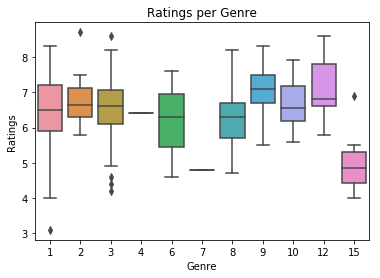

```python
plt.title("Ratings per Genre")
sns.boxplot(x="Genre", y="Ratings", data=df_cat_targ1)
plt.show()
```

The movie in the dataset with the highest rating of 8.7 is Interstellar (2014). The movie with the lowest rating of 3.1 is Left Behind (2014).

```python
display(df_clean[df_clean['Ratings'] == max(df_clean['Ratings'])])
display(df_clean[df_clean['Ratings'] == min(df_clean['Ratings'])])
```

|  | Movie | Year | Ratings | Genre | Gross | Budget | Screens | Sequel | Sentiment | Views | Likes | Dislikes | Comments |
| --- | --- | --- | --- | --- | --- | --- | --- | --- | --- | --- | --- | --- | --- |
| 55 | Interstellar | 2014 | 8.7 | 2 | 188000000 | 165000000.0 | 3561.0 | 1 | 2 | 5421705 | 16635 | 751 | 4316 |

|  | Movie | Year | Ratings | Genre | Gross | Budget | Screens | Sequel | Sentiment | Views | Likes | Dislikes | Comments |
| --- | --- | --- | --- | --- | --- | --- | --- | --- | --- | --- | --- | --- | --- |
| 65 | Left Behind | 2014 | 3.1 | 1 | 14000000 | 16000000.0 | 1825.0 | 1 | 0 | 5611593 | 11187 | 2111 | 7595 |

The chart below shows the distribution of gross income per genre. Genre 1 has the widest range of gross income. Movies under Genre 2 have the highest median gross income.

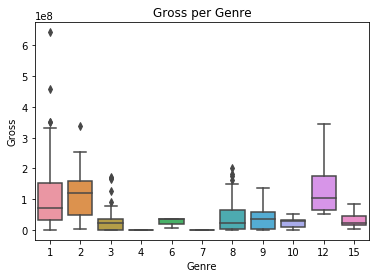

```python
plt.title("Gross per Genre")
sns.boxplot(x="Genre", y="Gross", data=df_cat_targ2)
plt.show()
```

The movie in the dataset with the highest gross income is Jurassic World (2015) while the movie with the lowest gross income is Locker 13.

```python
display(df_clean[df_clean['Gross'] == max(df_clean['Gross'])])
display(df_clean[df_clean['Gross'] == min(df_clean['Gross'])])
```

|  | Movie | Year | Ratings | Genre | Gross | Budget | Screens | Sequel | Sentiment | Views | Likes | Dislikes | Comments |
| --- | --- | --- | --- | --- | --- | --- | --- | --- | --- | --- | --- | --- | --- |
| 163 | Jurassic World | 2015 | 7.3 | 1 | 643000000 | 150000000.0 | 4274.0 | 4 | 1 | 9143740 | 34746 | 1074 | 5107 |

|  | Movie | Year | Ratings | Genre | Gross | Budget | Screens | Sequel | Sentiment | Views | Likes | Dislikes | Comments |
| --- | --- | --- | --- | --- | --- | --- | --- | --- | --- | --- | --- | --- | --- |
| 68 | Locker 13 | 2014 | 4.8 | 7 | 2470 | 300000.0 | 3.0 | 1 | 0 | 30529 | 18 | 4 | 2 |

Scatterplots below show relationship between ratings and numerical features in the dataset. Visually, it looks that Ratings are more correlated with budget and sequel.

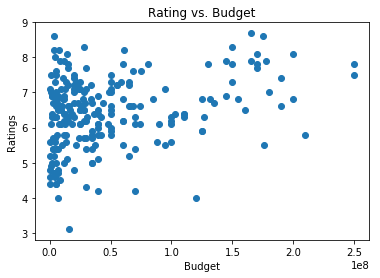

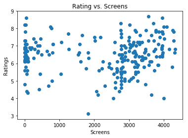

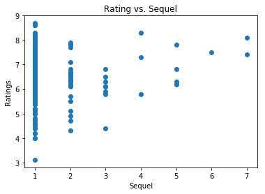

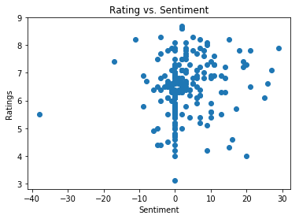

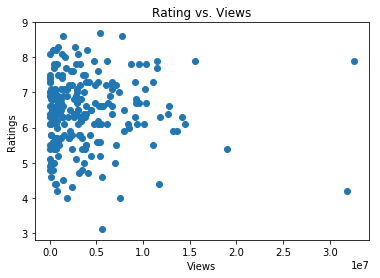

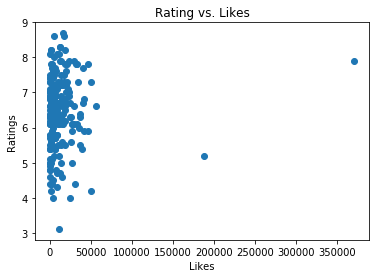

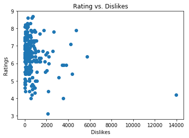

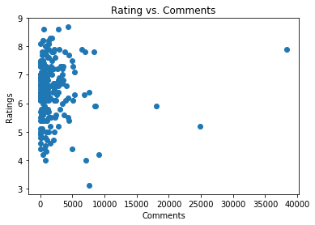

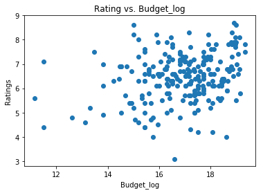

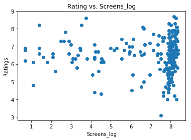

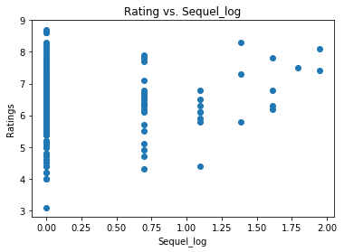

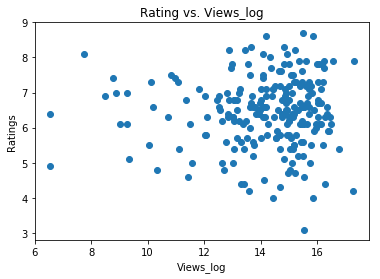

[3 more figures not shown]

```python
for col in range(len(df_num_targ1.columns)-1):
    plt.title("Rating vs. {}".format(df_num_targ1.columns[col]))
    plt.ylabel("Ratings")
    plt.xlabel(df_num_targ1.columns[col])
    plt.scatter((df_num_targ1.iloc[:, col]), y1)
    plt.show()
```

Scatterplots below show relationship between Gross Income and numerical features in the dataset. Visually, it looks that gross income is correlated with budget and screens.

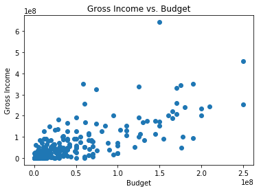

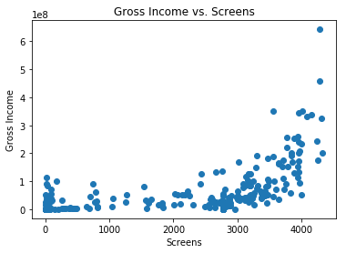

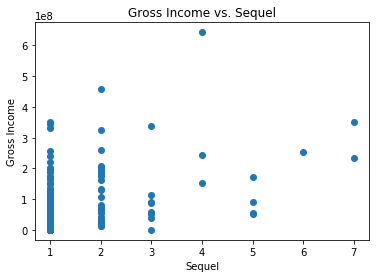

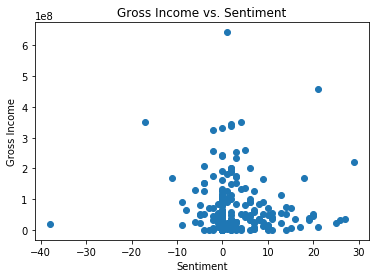

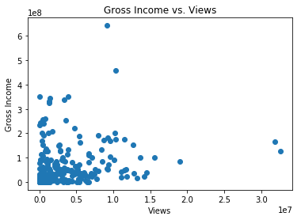

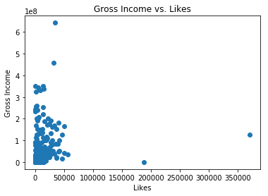

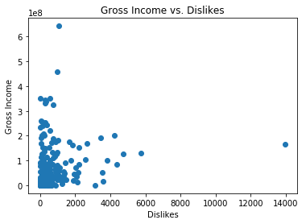

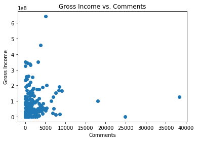

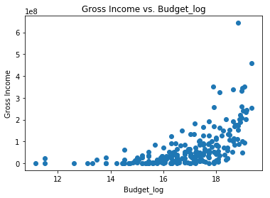

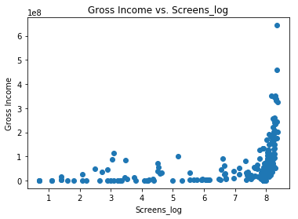

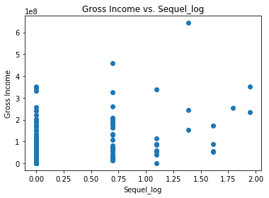

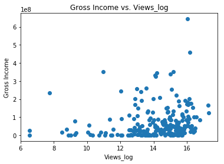

[3 more figures not shown]

```python
for col in range(len(df_num_targ2.columns)-1):
    plt.title("Gross Income vs. {}".format(df_num_targ2.columns[col]))
    plt.ylabel("Gross Income")
    plt.xlabel(df_num_targ2.columns[col])
    plt.scatter(df_num_targ2.iloc[:, col], y2)
    plt.show()
```

## Predicting Movie Ratings

K Nearest Neighbors Regression, Linear Regression, Ridge Regression, and Lasso Regression were the four regression algorithms used to predict Movie `Ratings`. Naturally, `Ratings` and `Gross Income`, the two variables being predicted, were removed from the features. The results were compared with each other and the algorithm that yields the highest "accuracy" measured in $r^2$ was identified.

#### Individual Features

The function below checks the accuracy of the regression model for each feature then returns the list of features from the one that gives the highest accuracy to the lowest accuracy.

```python
def ml_each_feature(X, y, t="knn_reg", params=range(1, 50),
                    seeds=range(0, 30), show=False):

    """
    Return a list of features and corresponding classification accuracy
    when each feature is taken one by one.
    """

    # First pass, checking each feature
    acc = []
    ml = ML_Regressor()

    for i in range(len(X.columns)):
        x = pd.DataFrame(X.iloc[:, i])

        a, p = ml.fit(x, y, ml_type=t, param_range=params,
                      seed_settings=seeds)
        acc.append(a)

    inds = np.argsort(acc)[::-1]
    sorted_acc = np.array(acc)[inds]
    cols = np.array(X.columns)[inds]

    if show == True:
        g = pd.DataFrame(sorted_acc, cols)
        g.columns = ['Accuracy']
        display(g.head(5))  # display top 5 predictors

    return cols  # return features from best predictor to least predictor
```

#### Combinations of Features

The function below checks combinations of features that give highest regression accuracy. It works by first calculating the accuracy using the most predictive feature, then adds the next most predictive feature. If accuracy increases, then the features are taken together before checking the next feature. If the accuracy decreases upon adding another feature, then this feature is skipped moving to the next one.

```python
def optimize_feats(X, y, cols, t="knn_reg", params=range(1, 50),
                   seeds=range(0, 30), plot=True, max_iter=10000):

    """
    Get features that will maximize classificationa accuracy
    """

    ml = ML_Regressor()

    lst = []  # indices of optimal feats
    accs = [0]  # accuracies
    p_opts = [0]  # optimal parameters

    for i in range(0, len(X.columns)):
        lst2 = lst[:]
        lst2.append(i)
        acc, p_opt = ml.fit(pd.DataFrame(X[cols[lst2]]), y, ml_type=t,
                            param_range=params, seed_settings=seeds, max_iter=max_iter)
        if acc > accs[-1]:
            accs.append(acc)
            p_opts.append(p_opt)
            lst.append(i)

    if plot == True:
        ml.fit(X[cols[lst]], y, ml_type=t,
               param_range=params, seed_settings=seeds, max_iter=max_iter)
        ml.plot(show_PCC=False)

    return accs[-1], p_opts[-1], lst
```

### One-Hot Encoding

First, the `Genre` feature was transformed to one-hot encoding. The idea is that per genre, the movie can either be under that genre (value = 1) or not (value = 0).

```python
enc="One-Hot"
```

```python
# One-hot encoding
df_cat2 = pd.get_dummies(df_cat.astype("str"), drop_first=True)
df_cat2.head()
```

|  | Genre_10 | Genre_12 | Genre_15 | Genre_2 | Genre_3 | Genre_4 | Genre_6 | Genre_7 | Genre_8 | Genre_9 |
| --- | --- | --- | --- | --- | --- | --- | --- | --- | --- | --- |
| 0 | 0 | 0 | 0 | 0 | 0 | 0 | 0 | 0 | 1 | 0 |
| 1 | 0 | 0 | 0 | 0 | 0 | 0 | 0 | 0 | 0 | 0 |
| 2 | 0 | 0 | 0 | 0 | 0 | 0 | 0 | 0 | 0 | 0 |
| 3 | 0 | 0 | 0 | 0 | 0 | 0 | 0 | 0 | 0 | 0 |
| 4 | 0 | 0 | 0 | 0 | 0 | 0 | 0 | 0 | 1 | 0 |

The dataframe with one-hot encoded genre is shown below.

```python
X0 = pd.concat([df_num_targ1, df_cat2], axis=1).drop("Ratings", axis=1)
conv_to_numeric(X0, range(0, len(X0.columns)));
X0.head()
```

```
No. of columns that must be changed to numerical: 25
No. of columns automatically changed to numbers, 1st pass: 25

Remaining columns with values that must be changed to numbers:
All values numerical already.
```

|  | Budget | Screens | Sequel | Sentiment | Views | Likes | Dislikes | Comments | Budget_log | Screens_log | ... | Genre_10 | Genre_12 | Genre_15 | Genre_2 | Genre_3 | Genre_4 | Genre_6 | Genre_7 | Genre_8 | Genre_9 |
| --- | --- | --- | --- | --- | --- | --- | --- | --- | --- | --- | --- | --- | --- | --- | --- | --- | --- | --- | --- | --- | --- |
| 0 | 4000000.0 | 45.0 | 1.0 | 0.0 | 3280543.0 | 4632.0 | 425.0 | 636.0 | 15.201805 | 3.806662 | ... | 0.0 | 0.0 | 0.0 | 0.0 | 0.0 | 0.0 | 0.0 | 0.0 | 1.0 | 0.0 |
| 1 | 50000000.0 | 3306.0 | 2.0 | 2.0 | 583289.0 | 3465.0 | 61.0 | 186.0 | 17.727534 | 8.103494 | ... | 0.0 | 0.0 | 0.0 | 0.0 | 0.0 | 0.0 | 0.0 | 0.0 | 0.0 | 0.0 |
| 2 | 28000000.0 | 2872.0 | 1.0 | 0.0 | 304861.0 | 328.0 | 34.0 | 47.0 | 17.147715 | 7.962764 | ... | 0.0 | 0.0 | 0.0 | 0.0 | 0.0 | 0.0 | 0.0 | 0.0 | 0.0 | 0.0 |
| 3 | 110000000.0 | 3470.0 | 2.0 | 0.0 | 452917.0 | 2429.0 | 132.0 | 590.0 | 18.515991 | 8.151910 | ... | 0.0 | 0.0 | 0.0 | 0.0 | 0.0 | 0.0 | 0.0 | 0.0 | 0.0 | 0.0 |
| 4 | 3500000.0 | 2310.0 | 2.0 | 0.0 | 3145573.0 | 12163.0 | 610.0 | 1082.0 | 15.068274 | 7.745003 | ... | 0.0 | 0.0 | 0.0 | 0.0 | 0.0 | 0.0 | 0.0 | 0.0 | 1.0 | 0.0 |

5 rows × 25 columns

### Scaling

Two scaling methods were used: min-max scaling or standard scaling. Min-max scaling scales the values in a column by the range of values in that column (minimum values to maximum values). Standard scaling scales the values in a column by the mean and standard deviation of the values in that column.

```python
# min-max scaling
mms = MinMaxScaler()
X_mm = pd.DataFrame(mms.fit_transform(X0), columns=X0.columns)
X_mm.head()
```

|  | Budget | Screens | Sequel | Sentiment | Views | Likes | Dislikes | Comments | Budget_log | Screens_log | ... | Genre_10 | Genre_12 | Genre_15 | Genre_2 | Genre_3 | Genre_4 | Genre_6 | Genre_7 | Genre_8 | Genre_9 |
| --- | --- | --- | --- | --- | --- | --- | --- | --- | --- | --- | --- | --- | --- | --- | --- | --- | --- | --- | --- | --- | --- |
| 0 | 0.015724 | 0.009949 | 0.000000 | 0.567164 | 0.100528 | 0.012498 | 0.030444 | 0.016578 | 0.494523 | 0.405470 | ... | 0.0 | 0.0 | 0.0 | 0.0 | 0.0 | 0.0 | 0.0 | 0.0 | 1.0 | 0.0 |
| 1 | 0.199776 | 0.764461 | 0.166667 | 0.597015 | 0.017857 | 0.009348 | 0.004370 | 0.004848 | 0.803265 | 0.965041 | ... | 0.0 | 0.0 | 0.0 | 0.0 | 0.0 | 0.0 | 0.0 | 0.0 | 0.0 | 0.0 |
| 2 | 0.111751 | 0.664044 | 0.000000 | 0.567164 | 0.009323 | 0.000882 | 0.002436 | 0.001225 | 0.732388 | 0.946714 | ... | 0.0 | 0.0 | 0.0 | 0.0 | 0.0 | 0.0 | 0.0 | 0.0 | 0.0 | 0.0 |
| 3 | 0.439843 | 0.802406 | 0.166667 | 0.567164 | 0.013861 | 0.006552 | 0.009456 | 0.015379 | 0.899644 | 0.971346 | ... | 0.0 | 0.0 | 0.0 | 0.0 | 0.0 | 0.0 | 0.0 | 0.0 | 0.0 | 0.0 |
| 4 | 0.013724 | 0.534012 | 0.166667 | 0.567164 | 0.096391 | 0.032821 | 0.043696 | 0.028204 | 0.478200 | 0.918355 | ... | 0.0 | 0.0 | 0.0 | 0.0 | 0.0 | 0.0 | 0.0 | 0.0 | 1.0 | 0.0 |

5 rows × 25 columns

```python
# standard scaling
stdsc = StandardScaler()

X_std=pd.DataFrame(stdsc.fit_transform(X0), columns=X0.columns)
X_std.head()
```

|  | Budget | Screens | Sequel | Sentiment | Views | Likes | Dislikes | Comments | Budget_log | Screens_log | ... | Genre_10 | Genre_12 | Genre_15 | Genre_2 | Genre_3 | Genre_4 | Genre_6 | Genre_7 | Genre_8 | Genre_9 |
| --- | --- | --- | --- | --- | --- | --- | --- | --- | --- | --- | --- | --- | --- | --- | --- | --- | --- | --- | --- | --- | --- |
| 0 | -0.810739 | -1.527274 | -0.372283 | -0.402417 | -0.096040 | -0.281630 | -0.204677 | -0.333876 | -1.135265 | -1.504973 | ... | -0.234082 | -0.244199 | -0.212718 | -0.234082 | -0.498647 | -0.065938 | -0.114708 | -0.093454 | 1.810463 | -0.244199 |
| 1 | 0.040033 | 0.748123 | 0.663831 | -0.115951 | -0.695253 | -0.322203 | -0.497933 | -0.460163 | 0.549579 | 0.609956 | ... | -0.234082 | -0.244199 | -0.212718 | -0.234082 | -0.498647 | -0.065938 | -0.114708 | -0.093454 | -0.552345 | -0.244199 |
| 2 | -0.366858 | 0.445295 | -0.372283 | -0.402417 | -0.757108 | -0.431267 | -0.519686 | -0.499172 | 0.162798 | 0.540688 | ... | -0.234082 | -0.244199 | -0.212718 | -0.234082 | -0.498647 | -0.065938 | -0.114708 | -0.093454 | -0.552345 | -0.244199 |
| 3 | 1.149735 | 0.862556 | 0.663831 | -0.402417 | -0.724216 | -0.358222 | -0.440732 | -0.346785 | 1.075538 | 0.633787 | ... | -0.234082 | -0.244199 | -0.212718 | -0.234082 | -0.498647 | -0.065938 | -0.114708 | -0.093454 | -0.552345 | -0.244199 |
| 4 | -0.819987 | 0.053154 | 0.663831 | -0.402417 | -0.126025 | -0.019801 | -0.055632 | -0.208711 | -1.224340 | 0.433504 | ... | -0.234082 | -0.244199 | -0.212718 | -0.234082 | -0.498647 | -0.065938 | -0.114708 | -0.093454 | 1.810463 | -0.244199 |

5 rows × 25 columns

Ratings values stored in `y1` was copied to `y` for modelign purposes.

```python
y = y1
```

The number of iterations was set to 100 as coded through the seeds parameter from 0 to 99 below.

```python
seeds = range(0, 100) # 0 to 99 excluding 100
```

#### X Min-Max Scaled

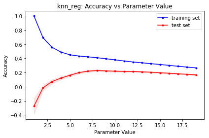

```
Report:
=======
Max average accuracy: 0.2281
Var of accuracy at optimal parameter: 0.0126
Optimal parameter: 8.0000
Total iterations: 100
```

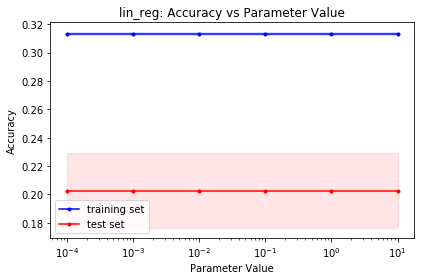

```
Report:
=======
Max average accuracy: 0.2026
Var of accuracy at optimal parameter: 0.0264
Optimal parameter: 0.0001
Total iterations: 100
```

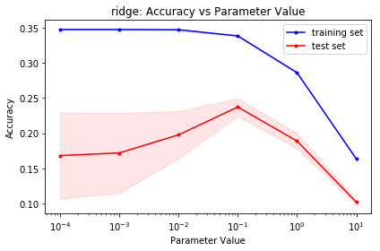

```
Report:
=======
Max average accuracy: 0.2373
Var of accuracy at optimal parameter: 0.0128
Optimal parameter: 0.1000
Total iterations: 100
```

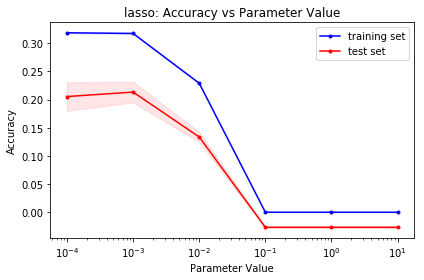

```
Report:
=======
Max average accuracy: 0.2134
Var of accuracy at optimal parameter: 0.0185
Optimal parameter: 0.0010
Total iterations: 100
```

```python
X = X_mm

params_knn = range(1, 20)
params_lr_svd = [0.0001, 0.001, 0.01, 0.1, 1, 10]

accuracies = []
opt_param = []
num_feats = []

types = ['knn_reg', 'lin_reg', 'ridge', 'lasso']

for t in types:
    if t == "knn_reg":
        params = params_knn
        cols = ml_each_feature(X, y, t=t, params=params, seeds=seeds)
        a, p, ind = optimize_feats(X, y, cols, t=t, params=params,
                                   seeds=seeds, plot=True)

        accuracies.append(a)
        opt_param.append(p)
        num_feats.append(len(ind))

    else:
        params = params_lr_svd
        cols = ml_each_feature(X, y, t=t, params=params, seeds=seeds)
        a, p, ind = optimize_feats(X, y, cols, t=t, params=params,
                                   seeds=seeds, plot=True, max_iter=10000)

        accuracies.append(a)
        opt_param.append(p)
        num_feats.append(len(ind))
```

```python
models = pd.Series(['kNN Reg', 'Linear Reg', 'Ridge',
                    'Lasso'],
                   name='Machine Learning Method')
accs = pd.Series(accuracies, name='Test Accuracy')
params = pd.Series(['n neighbors', 'C', 'C', 'C'], name='Parameter')
param_val_2 = pd.Series(opt_param, name='Optimal Parameter Value')
encoder = pd.Series([enc]*4, name="Encoder")
scaling = pd.Series(["Min-Max"] * 4, name="Scaling")
features = pd.Series(num_feats, name="Features")
df_2 = pd.concat([encoder, scaling, features, models, accs,
                  params, param_val_2], axis=1)
display(df_2)
```

|  | Encoder | Scaling | Features | Machine Learning Method | Test Accuracy | Parameter | Optimal Parameter Value |
| --- | --- | --- | --- | --- | --- | --- | --- |
| 0 | One-Hot | Min-Max | 10 | kNN Reg | 0.2281 | n neighbors | 8.0000 |
| 1 | One-Hot | Min-Max | 8 | Linear Reg | 0.2026 | C | 0.0001 |
| 2 | One-Hot | Min-Max | 11 | Ridge | 0.2373 | C | 0.1000 |
| 3 | One-Hot | Min-Max | 9 | Lasso | 0.2134 | C | 0.0010 |

#### X Std Scaled

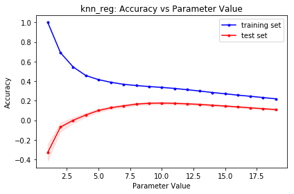

```
Report:
=======
Max average accuracy: 0.1761
Var of accuracy at optimal parameter: 0.0118
Optimal parameter: 10.0000
Total iterations: 100
```

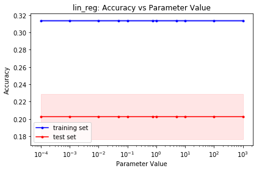

```
Report:
=======
Max average accuracy: 0.2027
Var of accuracy at optimal parameter: 0.0263
Optimal parameter: 0.0001
Total iterations: 100
```

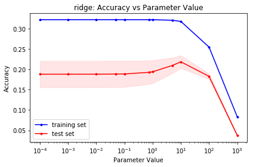

```
Report:
=======
Max average accuracy: 0.2185
Var of accuracy at optimal parameter: 0.0155
Optimal parameter: 10.0000
Total iterations: 100
```

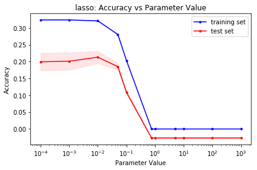

```
Report:
=======
Max average accuracy: 0.2129
Var of accuracy at optimal parameter: 0.0180
Optimal parameter: 0.0100
Total iterations: 100
```

```python
X = X_std

params_knn = range(1, 20)
params_lr_svd = [0.0001, 0.001, 0.01, 0.05, 0.1, 0.75, 1, 5, 10, 100, 1000]

accuracies = []
opt_param = []
num_feats = []

types = ['knn_reg', 'lin_reg', 'ridge', 'lasso']

for t in types:
    if t == "knn_reg":
        params = params_knn
        cols = ml_each_feature(X, y, t=t, params=params, seeds=seeds)
        a, p, ind = optimize_feats(X, y, cols, t=t, params=params,
                                   seeds=seeds, plot=True)

        accuracies.append(a)
        opt_param.append(p)
        num_feats.append(len(ind))

    else:
        params = params_lr_svd
        cols = ml_each_feature(X, y, t=t, params=params, seeds=seeds)
        a, p, ind = optimize_feats(X, y, cols, t=t, params=params,
                                   seeds=seeds, plot=True, max_iter=10000)

        accuracies.append(a)
        opt_param.append(p)
        num_feats.append(len(ind))
```

```python
models = pd.Series(['kNN Reg', 'Linear Reg', 'Ridge',
                    'Lasso'],
                   name='Machine Learning Method')
accs = pd.Series(accuracies, name='Test Accuracy')
params = pd.Series(['n neighbors', 'C', 'C', 'C'], name='Parameter')
param_val_2 = pd.Series(opt_param, name='Optimal Parameter Value')
encoder = pd.Series([enc]*4, name="Encoder")
scaling = pd.Series(["Std"] * 4, name="Scaling")
features = pd.Series(num_feats, name="Features")
df_3 = pd.concat([encoder, scaling, features, models, accs,
                  params, param_val_2], axis=1)
display(df_3)
```

|  | Encoder | Scaling | Features | Machine Learning Method | Test Accuracy | Parameter | Optimal Parameter Value |
| --- | --- | --- | --- | --- | --- | --- | --- |
| 0 | One-Hot | Std | 10 | kNN Reg | 0.1761 | n neighbors | 10.0000 |
| 1 | One-Hot | Std | 9 | Linear Reg | 0.2027 | C | 0.0001 |
| 2 | One-Hot | Std | 10 | Ridge | 0.2185 | C | 10.0000 |
| 3 | One-Hot | Std | 9 | Lasso | 0.2129 | C | 0.0100 |

### Predicting Movie Ratings Summary

The table below summarizes the results of the runs above. Highest regression accuracy ($r^2$) was achieved using one-hot encoding, min-max scaling, ridge regression, parameter value of 0.100 and 11 features.

```python
df_all_1 = pd.concat([df_2, df_3]).reset_index(drop=True)
df_all_1 = df_all_1.sort_values(by="Test Accuracy", ascending=False).reset_index(drop=True)
df_all_1
```

|  | Encoder | Scaling | Features | Machine Learning Method | Test Accuracy | Parameter | Optimal Parameter Value |
| --- | --- | --- | --- | --- | --- | --- | --- |
| 0 | One-Hot | Min-Max | 11 | Ridge | 0.2373 | C | 0.1000 |
| 1 | One-Hot | Min-Max | 10 | kNN Reg | 0.2281 | n neighbors | 8.0000 |
| 2 | One-Hot | Std | 10 | Ridge | 0.2185 | C | 10.0000 |
| 3 | One-Hot | Min-Max | 9 | Lasso | 0.2134 | C | 0.0010 |
| 4 | One-Hot | Std | 9 | Lasso | 0.2129 | C | 0.0100 |
| 5 | One-Hot | Std | 9 | Linear Reg | 0.2027 | C | 0.0001 |
| 6 | One-Hot | Min-Max | 8 | Linear Reg | 0.2026 | C | 0.0001 |
| 7 | One-Hot | Std | 10 | kNN Reg | 0.1761 | n neighbors | 10.0000 |

### Predicting Using Best Method

The selected model was rerun below.

```python
enc="One-Hot"
```

```python
# One-hot encoding
df_cat2 = pd.get_dummies(df_cat.astype("str"), drop_first=True)
```

```python
X0 = pd.concat([df_num_targ1, df_cat2], axis=1).drop("Ratings", axis=1)
conv_to_numeric(X0, range(0, len(X0.columns)));
```

```
No. of columns that must be changed to numerical: 25
No. of columns automatically changed to numbers, 1st pass: 25

Remaining columns with values that must be changed to numbers:
All values numerical already.
```

```python
# min-max scaling
mms = MinMaxScaler()
X_mm = pd.DataFrame(mms.fit_transform(X0), columns=X0.columns)
```

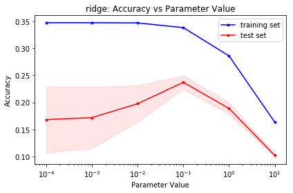

```
Report:
=======
Max average accuracy: 0.2373
Var of accuracy at optimal parameter: 0.0128
Optimal parameter: 0.1000
Total iterations: 100
```

```python
X = X_mm

params = [0.0001, 0.001, 0.01, 0.1, 1, 10]

accuracies = []
opt_param = []
num_feats = []

t = 'ridge'
cols = ml_each_feature(X, y, t=t, params=params, seeds=seeds)
a, p, ind = optimize_feats(X, y, cols, t=t, params=params,
                                   seeds=seeds, plot=True, max_iter=10000)
```

The chart below shows the 11 features used. The number of likes is the top predictor, correlating positively with ratings. Comments and dislikes are the next two predictors, correlating negatively with ratings.

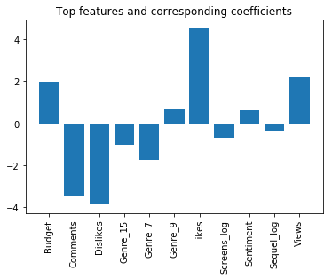

```python
ml = ML_Regressor()
ml.fit(X[cols[ind]], y, ml_type=t, param_range=params, seed_settings=seeds)
plt.bar(cols[ind], ml.coefs_all)
plt.title("Top features and corresponding coefficients")
plt.xticks(rotation=90);
```

## Predicting Gross Income

K Nearest Neighbors Regression, Linear Regression, Ridge Regression, and Lasso Regression were the four regression algorithms used to predict Movie `Gross Income`. Naturally, `Ratings` and `Gross Income`, the two variables being predicted, were removed from the features. The results were compared with each other and the algorithm that yields the highest "accuracy" measured in $r^2$ was identified.

### Scaling

Two scaling methods were used: min-max scaling or standard scaling. Min-max scaling scales the values in a column by the range of values in that column (minimum values to maximum values). Standard scaling scales the values in a column by the mean and standard deviation of the values in that column.

```python
# min-max scaling
mms = MinMaxScaler()
X_mm = pd.DataFrame(mms.fit_transform(X0), columns=X0.columns)
```

```python
# standard scaling
stdsc = StandardScaler()

X_std=pd.DataFrame(stdsc.fit_transform(X0), columns=X0.columns)
```

```python
y = (y2)
```

#### X Min-Max Scaled

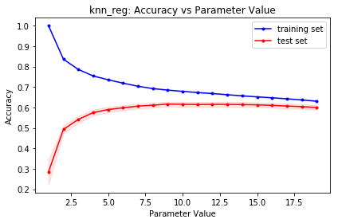

```
Report:
=======
Max average accuracy: 0.6171
Var of accuracy at optimal parameter: 0.0117
Optimal parameter: 9.0000
Total iterations: 100
```

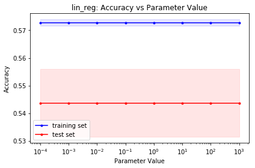

```
Report:
=======
Max average accuracy: 0.5436
Var of accuracy at optimal parameter: 0.0122
Optimal parameter: 0.0001
Total iterations: 100
```

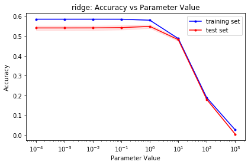

```
Report:
=======
Max average accuracy: 0.5488
Var of accuracy at optimal parameter: 0.0092
Optimal parameter: 1.0000
Total iterations: 100
```

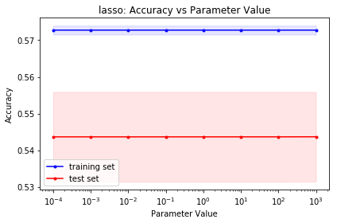

```
Report:
=======
Max average accuracy: 0.5437
Var of accuracy at optimal parameter: 0.0122
Optimal parameter: 1000.0000
Total iterations: 100
```

```python
X = X_mm

params_knn = range(1, 20)
params_lr_svd = [0.0001, 0.001, 0.01, 0.1, 1, 10, 100, 1000]

accuracies = []
opt_param = []
num_feats = []

types = ['knn_reg', 'lin_reg', 'ridge', 'lasso']

for t in types:
    if t == "knn_reg":
        params = params_knn
        cols = ml_each_feature(X, y, t=t, params=params, seeds=seeds)
        a, p, ind = optimize_feats(X, y, cols, t=t, params=params,
                                   seeds=seeds, plot=True)

        accuracies.append(a)
        opt_param.append(p)
        num_feats.append(len(ind))

    else:
        params = params_lr_svd
        cols = ml_each_feature(X, y, t=t, params=params, seeds=seeds)
        a, p, ind = optimize_feats(X, y, cols, t=t, params=params,
                                   seeds=seeds, plot=True, max_iter=10000)

        accuracies.append(a)
        opt_param.append(p)
        num_feats.append(len(ind))
```

```python
models = pd.Series(['kNN Reg', 'Linear Reg', 'Ridge',
                    'Lasso'],
                   name='Machine Learning Method')
accs = pd.Series(accuracies, name='Test Accuracy')
params = pd.Series(['n neighbors', 'C', 'C', 'C'], name='Parameter')
param_val_2 = pd.Series(opt_param, name='Optimal Parameter Value')
encoder = pd.Series([enc]*4, name="Encoder")
scaling = pd.Series(["Min-Max"] * 4, name="Scaling")
features = pd.Series(num_feats, name="Features")
df_22 = pd.concat([encoder, scaling, features, models, accs,
                  params, param_val_2], axis=1)
display(df_22)
```

|  | Encoder | Scaling | Features | Machine Learning Method | Test Accuracy | Parameter | Optimal Parameter Value |
| --- | --- | --- | --- | --- | --- | --- | --- |
| 0 | One-Hot | Min-Max | 8 | kNN Reg | 0.6171 | n neighbors | 9.0000 |
| 1 | One-Hot | Min-Max | 5 | Linear Reg | 0.5436 | C | 0.0001 |
| 2 | One-Hot | Min-Max | 7 | Ridge | 0.5488 | C | 1.0000 |
| 3 | One-Hot | Min-Max | 5 | Lasso | 0.5437 | C | 1000.0000 |

#### X Std Scaled

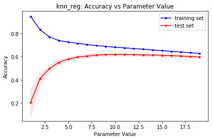

```
Report:
=======
Max average accuracy: 0.6196
Var of accuracy at optimal parameter: 0.0118
Optimal parameter: 11.0000
Total iterations: 100
```

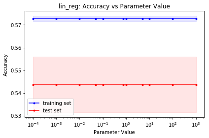

```
Report:
=======
Max average accuracy: 0.5436
Var of accuracy at optimal parameter: 0.0122
Optimal parameter: 0.0001
Total iterations: 100
```

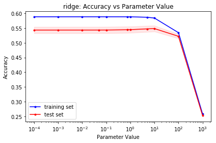

```
Report:
=======
Max average accuracy: 0.5482
Var of accuracy at optimal parameter: 0.0101
Optimal parameter: 10.0000
Total iterations: 100
```

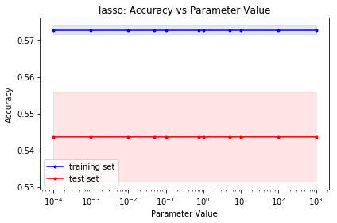

```
Report:
=======
Max average accuracy: 0.5436
Var of accuracy at optimal parameter: 0.0122
Optimal parameter: 1000.0000
Total iterations: 100
```

```python
X = X_std

params_knn = range(1, 20)
params_lr_svd = [0.0001, 0.001, 0.01, 0.05, 0.1, 0.75, 1, 5, 10, 100, 1000]

accuracies = []
opt_param = []
num_feats = []

types = ['knn_reg', 'lin_reg', 'ridge', 'lasso']

for t in types:
    if t == "knn_reg":
        params = params_knn
        cols = ml_each_feature(X, y, t=t, params=params, seeds=seeds)
        a, p, ind = optimize_feats(X, y, cols, t=t, params=params,
                                   seeds=seeds, plot=True)

        accuracies.append(a)
        opt_param.append(p)
        num_feats.append(len(ind))

    else:
        params = params_lr_svd
        cols = ml_each_feature(X, y, t=t, params=params, seeds=seeds)
        a, p, ind = optimize_feats(X, y, cols, t=t, params=params,
                                   seeds=seeds, plot=True, max_iter=10000)

        accuracies.append(a)
        opt_param.append(p)
        num_feats.append(len(ind))
```

```python
models = pd.Series(['kNN Reg', 'Linear Reg', 'Ridge',
                    'Lasso'],
                   name='Machine Learning Method')
accs = pd.Series(accuracies, name='Test Accuracy')
params = pd.Series(['n neighbors', 'C', 'C', 'C'], name='Parameter')
param_val_2 = pd.Series(opt_param, name='Optimal Parameter Value')
encoder = pd.Series([enc]*4, name="Encoder")
scaling = pd.Series(["Std"] * 4, name="Scaling")
features = pd.Series(num_feats, name="Features")
df_23 = pd.concat([encoder, scaling, features, models, accs,
                  params, param_val_2], axis=1)
display(df_23)
```

|  | Encoder | Scaling | Features | Machine Learning Method | Test Accuracy | Parameter | Optimal Parameter Value |
| --- | --- | --- | --- | --- | --- | --- | --- |
| 0 | One-Hot | Std | 5 | kNN Reg | 0.6196 | n neighbors | 11.0000 |
| 1 | One-Hot | Std | 5 | Linear Reg | 0.5436 | C | 0.0001 |
| 2 | One-Hot | Std | 6 | Ridge | 0.5482 | C | 10.0000 |
| 3 | One-Hot | Std | 5 | Lasso | 0.5436 | C | 1000.0000 |

### Predicting Gross Income Summary

```python
df_all_2 = pd.concat([df_22, df_23]).reset_index(drop=True)
df_all_2 = df_all_2.sort_values(by="Test Accuracy", ascending=False).reset_index(drop=True)
df_all_2
```

|  | Encoder | Scaling | Features | Machine Learning Method | Test Accuracy | Parameter | Optimal Parameter Value |
| --- | --- | --- | --- | --- | --- | --- | --- |
| 0 | One-Hot | Std | 5 | kNN Reg | 0.6196 | n neighbors | 11.0000 |
| 1 | One-Hot | Min-Max | 8 | kNN Reg | 0.6171 | n neighbors | 9.0000 |
| 2 | One-Hot | Min-Max | 7 | Ridge | 0.5488 | C | 1.0000 |
| 3 | One-Hot | Std | 6 | Ridge | 0.5482 | C | 10.0000 |
| 4 | One-Hot | Min-Max | 5 | Lasso | 0.5437 | C | 1000.0000 |
| 5 | One-Hot | Min-Max | 5 | Linear Reg | 0.5436 | C | 0.0001 |
| 6 | One-Hot | Std | 5 | Linear Reg | 0.5436 | C | 0.0001 |
| 7 | One-Hot | Std | 5 | Lasso | 0.5436 | C | 1000.0000 |

### Predicting Using Best Method

The selected model was rerun below.

```python
enc="One-Hot"
```

```python
# One-hot encoding
df_cat2 = pd.get_dummies(df_cat.astype("str"), drop_first=True)
```

```python
X0 = pd.concat([df_num_targ1, df_cat2], axis=1).drop("Ratings", axis=1)
conv_to_numeric(X0, range(0, len(X0.columns)));
```

```
No. of columns that must be changed to numerical: 25
No. of columns automatically changed to numbers, 1st pass: 25

Remaining columns with values that must be changed to numbers:
All values numerical already.
```

```python
# min-max scaling
X_std = pd.DataFrame(stdsc.fit_transform(X0), columns=X0.columns)
```

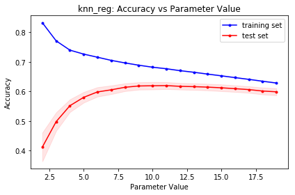

```
Report:
=======
Max average accuracy: 0.6196
Var of accuracy at optimal parameter: 0.0118
Optimal parameter: 11.0000
Total iterations: 100
```

```python
X = X_std

params = range(2, 20)

accuracies = []
opt_param = []
num_feats = []

t = 'knn_reg'
cols = ml_each_feature(X, y, t=t, params=params, seeds=seeds)
a, p, ind = optimize_feats(X, y, cols, t=t, params=params,
                                   seeds=seeds, plot=True)
```

```python
cols[ind]
```

```
array(['Screens_log', 'Screens', 'Genre_12', 'Genre_7', 'Genre_6'],
      dtype=object)
```

## Summary

```python
df_best = pd.concat([df_all_1.iloc[[0]], df_all_2.iloc[[0]]])
df_best.head()
```

|  | Encoder | Scaling | Features | Machine Learning Method | Test Accuracy | Parameter | Optimal Parameter Value |
| --- | --- | --- | --- | --- | --- | --- | --- |
| 0 | One-Hot | Min-Max | 11 | Ridge | 0.2373 | C | 0.1 |
| 0 | One-Hot | Std | 5 | kNN Reg | 0.6196 | n neighbors | 11.0 |

Various combinations of categorical data encoding, features scaling, and regression algorithms were run on a movies dataset prepared by Mehreen Ahmed of the National University of Sciences and Technology (NUST), Pakistan. The goal was to predict the gross income and rating based on features sourced from IMDB, Youtube, and Twitter.

23.73% was the highest coefficient of determination $r^2$ achieved when predicting movie ratings. The regression algorithm used is Ridge Regression with parameter $\alpha = 0.1$. One-hot encoding was applied on the genre feature, and min-max scaling was applied on each of the feature. A total of 11 features were used namely:

1. Likes
2. Dislikes
3. Comments
4. Views
5. Budget
6. Genre_7
7. Genre_15
8. Genre_9
9. Screens_log
10. Sentiment
11. Sequel_log

The number of likes on the movie trailer on Youtube is the feature with the largest positive coefficent. The number of comments on Youtube trailers has the largest negative coefficient, followed closely by the number of dislikes.

When predicting gross income, the highest $r^2$ of 61.96% was achieved using kNN Regression using 11 neighbors. One-hot encoding was applied on the genre feature, and standard scaling was applied on each of the feature. A total of five features were used namely:

1. Screens_log
2. Screens
3. Genre_12
4. Genre_7
5. Genre_6

## Limitations and Avenues for Further Research

The dataset used only spanned from 2014 to 2015, and only used Twitter and Youtube data. Further studies could explore to expand to capture more years as well as more video and social media sites. Feature engineering may also improve accuracy in the future.

## References and Acknowledgements

I would like to acknowledge Prof. Monterola, Prof. Legara, and the rest of AIM Access lab Professors and lab team.

Data was sourced from https://archive.ics.uci.edu/ml/datasets/CSM+%28Conventional+and+Social+Media+Movies%29+Dataset+2014+and+2015

Ahmed M, Jahangir M, Afzal H, Majeed A, Siddiqi I. Using Crowd-source based features from social media and Conventional features to predict the movies popularity. InSmart City/SocialCom/SustainCom (SmartCity), 2015 IEEE International Conference on 2015 Dec 19 (pp. 273-278). IEEE.